# COMP 162: Analyzing Data with R

2026-03-05

# Winter Olympics Data Analysis

Alessia Couchond & Nico Rating

## **INTRODUCTION**

### Dataset Source

**Dataset:** *120 Years of Olympic History: Athletes and Results*  
**Source:** Kaggle  
**Link:** https://www.kaggle.com/datasets/heesoo37/120-years-of-olympic-history-athletes-and-results

### Description of the Dataset

- Each row represents one athlete competing in one Olympic event.
- The full dataset includes **271,116 observations** and **15 variables**.

For this project, we restricted the dataset to:

- **Winter Olympic Games**
- **Years 1980 and later**

This allows us to focus on modern athletic trends and maintain consistency across training, competition level, and sport structure.

#### Key Variables Used in This Analysis

| Variable | Description | Variable Type |
| --- | --- | --- |
| **Sex** | Athlete’s gender (Male or Female) | Binary |
| **Age** | Athlete’s age at the time of competition | Discrete |
| **Height** | Height in centimeters | Continuous |
| **Weight** | Weight in kilograms | Continuous |
| **NOC** | National Olympic Committee code (country) | Nominal |
| **Year** | Year of the Olympic Games | Discrete |
| **Season** | Winter or Summer | Binary/Nominal |
| **Sport** | Sport category | Nominal |
| **Medal** | Gold, Silver, Bronze, or NA (no medal) | Ordinal |

### Motivation for Studying This Dataset

As student-athletes, we are interested in understanding trends in elite athletic performance. The Olympic Games represent the highest level of international competition, making this dataset ideal for analyzing long-term performance patterns.

Some of the questions we are interested in exploring include:

- Are certain physical characteristics (age, height, weight) more common among medal winners?
- Are there differences between male and female athletes?
- Is there a relationship between athlete age and medal type across different winter sports?
- Has the average age of Winter Olympic athletes changed over time?
- Are some countries more dominant in specific winter sports since 1980?

The Winter Olympics provide a unique opportunity to explore these questions because they include elite competitors from many countries over multiple decades. This project also allows us to connect our athletic background with data analysis techniques learned in COMP 162.

### Basic Summary Statistics

We created a filtered dataset including only Winter Olympics from 1980:

```r
olympics <- read_csv("athlete_events.csv")
sub_olympics <- select(olympics, ID, Sex, Age, Height, Weight, NOC, Year, Season, Sport, Medal)
view(sub_olympics)

new_olympics <- filter(sub_olympics, Season == "Winter", Year >= 1980)
view(new_olympics)
```

```r
new_olympics <- arrange(new_olympics, Sport, Year)
view(new_olympics)
```

```r
head(new_olympics)
```

```
## # A tibble: 6 × 10
##      ID Sex     Age Height Weight NOC    Year Season Sport         Medal
##   <dbl> <chr> <dbl>  <dbl>  <dbl> <chr> <dbl> <chr>  <chr>         <chr>
## 1   938 M        26    173     74 USA    1980 Winter Alpine Skiing <NA>
## 2  3094 F        19     NA     NA AUS    1980 Winter Alpine Skiing <NA>
## 3  3094 F        19     NA     NA AUS    1980 Winter Alpine Skiing <NA>
## 4  3837 M        26    173     78 USA    1980 Winter Alpine Skiing <NA>
## 5  4177 M        22    183     77 URS    1980 Winter Alpine Skiing <NA>
## 6  4177 M        22    183     77 URS    1980 Winter Alpine Skiing <NA>
```

```r
str(new_olympics)
```

```
## tibble [34,504 × 10] (S3: tbl_df/tbl/data.frame)
##  $ ID    : num [1:34504] 938 3094 3094 3837 4177 ...
##  $ Sex   : chr [1:34504] "M" "F" "F" "M" ...
##  $ Age   : num [1:34504] 26 19 19 26 22 22 21 21 18 18 ...
##  $ Height: num [1:34504] 173 NA NA 173 183 183 169 169 NA NA ...
##  $ Weight: num [1:34504] 74 NA NA 78 77 77 65 65 NA NA ...
##  $ NOC   : chr [1:34504] "USA" "AUS" "AUS" "USA" ...
##  $ Year  : num [1:34504] 1980 1980 1980 1980 1980 1980 1980 1980 1980 1980 ...
##  $ Season: chr [1:34504] "Winter" "Winter" "Winter" "Winter" ...
##  $ Sport : chr [1:34504] "Alpine Skiing" "Alpine Skiing" "Alpine Skiing" "Alpine Skiing" ...
##  $ Medal : chr [1:34504] NA NA NA NA ...
```

The new dataset has 34,504 rows and 10 columns.

```r
summary(new_olympics)
```

```
##        ID             Sex                 Age            Height
##  Min.   :     5   Length:34504       Min.   :11.00   Min.   :142
##  1st Qu.: 37897   Class :character   1st Qu.:22.00   1st Qu.:168
##  Median : 68423   Mode  :character   Median :25.00   Median :175
##  Mean   : 70001                      Mean   :25.13   Mean   :175
##  3rd Qu.:103861                      3rd Qu.:28.00   3rd Qu.:182
##  Max.   :135571                      Max.   :55.00   Max.   :206
##                                      NA's   :21      NA's   :2128
##      Weight           NOC                 Year         Season
##  Min.   : 32.00   Length:34504       Min.   :1980   Length:34504
##  1st Qu.: 61.00   Class :character   1st Qu.:1992   Class :character
##  Median : 70.00   Mode  :character   Median :2002   Mode  :character
##  Mean   : 70.97                      Mean   :2000
##  3rd Qu.: 80.00                      3rd Qu.:2010
##  Max.   :127.00                      Max.   :2014
##  NA's   :2406
##     Sport              Medal
##  Length:34504       Length:34504
##  Class :character   Class :character
##  Mode  :character   Mode  :character
##
##
##
##
```

## **VISUALIZATIONS**

### 1. Relationship Between Two Quantitative Variables

#### **Height vs Weight (Faceted by Sex)**

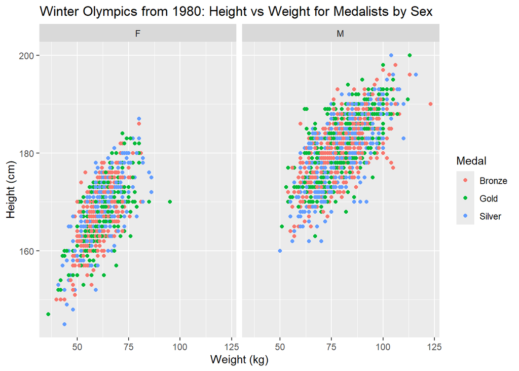

```r
new_olympics %>%
  filter(!is.na(Medal)) %>%
  ggplot(aes(Weight, Height,
             color = Medal)) +
  geom_point() +
  facet_wrap(~Sex) +
  labs(title = "Winter Olympics from 1980: Height vs Weight for Medalists by Sex",
    x = "Weight (kg)",
    y = "Height (cm)",
  )
```

**Interpretation:** There is a clear relationship between height and weight for both men and women; in general, taller athletes weigh more. Male athletes are usually taller and heavier than female athletes, but the pattern is similar within each group. The medal groups look very similar, suggesting that height and weight don’t influence the medal outcome.

### 2. Relationship Between a Categorical and a Quantitative Variable

#### **Age Distribution by Sport**

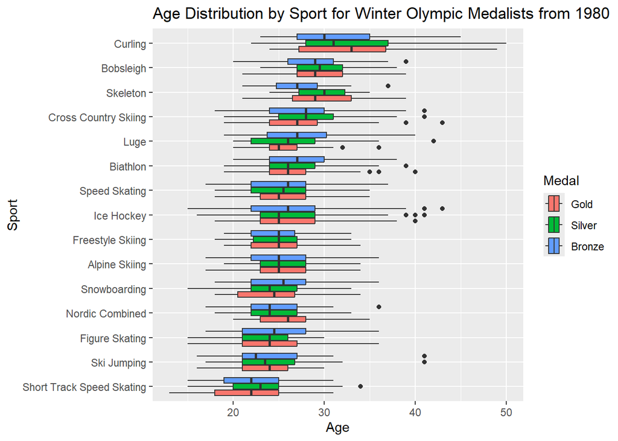

```r
new_olympics %>%
  filter(!is.na(Medal)) %>%
  ggplot(aes(Age, reorder(Sport, Age, FUN=median, na.rm = TRUE),
             fill = factor(Medal, levels = c("Gold", "Silver", "Bronze")))) +
  geom_boxplot() +
  labs(title = "Age Distribution by Sport for Winter Olympic Medalists from 1980",
       y = "Sport",
       fill = "Medal")
```

**Interpretation:** Age is different depending on the sport. Some sports, like figure skating, usually have younger medalists, while others, like curling, have older athletes. Within each sport, the different medal types look very similar in age, which suggests that age depends more on the sport than on the type of medal won.

#### **Medal Count by Sport for Top 5 Countries**

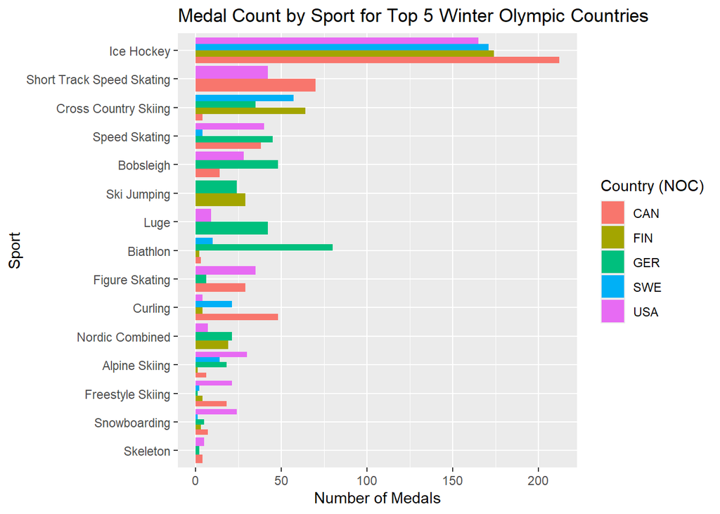

```r
top5 <- new_olympics %>%
  filter(!is.na(Medal)) %>%
  group_by(NOC) %>%
  summarise(total_medals = n()) %>%
  arrange(desc(total_medals)) %>%
  head(5)

new_olympics %>%
  filter(!is.na(Medal), NOC %in% top5$NOC) %>%
  count(Sport, NOC) %>%
  ggplot(aes(n, reorder(Sport, n), fill = NOC)) +
  geom_col(position = "dodge") +
  labs(
    title = "Medal Count by Sport for Top 5 Winter Olympic Countries",
    x = "Number of Medals",
    y = "Sport",
    fill = "Country (NOC)")
```

**Interpretation:** The results show that certain countries dominate specific winter sports. For example, Canada is especially strong in Ice Hockey, while Germany performs strongly in Biathlon; Nordic countries such as Finland and Sweden tend to lead in Cross Country Skiing. Overall, dominance is sport-specific, with countries specializing in particular events rather than dominating all winter sports equally.

## **DATASET MANIPULATIONS**

In this section, we used dplyr functions such as group_by() and summarize() to calculate the average age of Winter Olympic athletes over time by sex. By grouping the data by year and gender, we were able to observe trends in age across different Olympic Games and compare patterns between male and female athletes. This manipulation allowed us to identify meaningful trends that are not immediately visible in the original dataset.

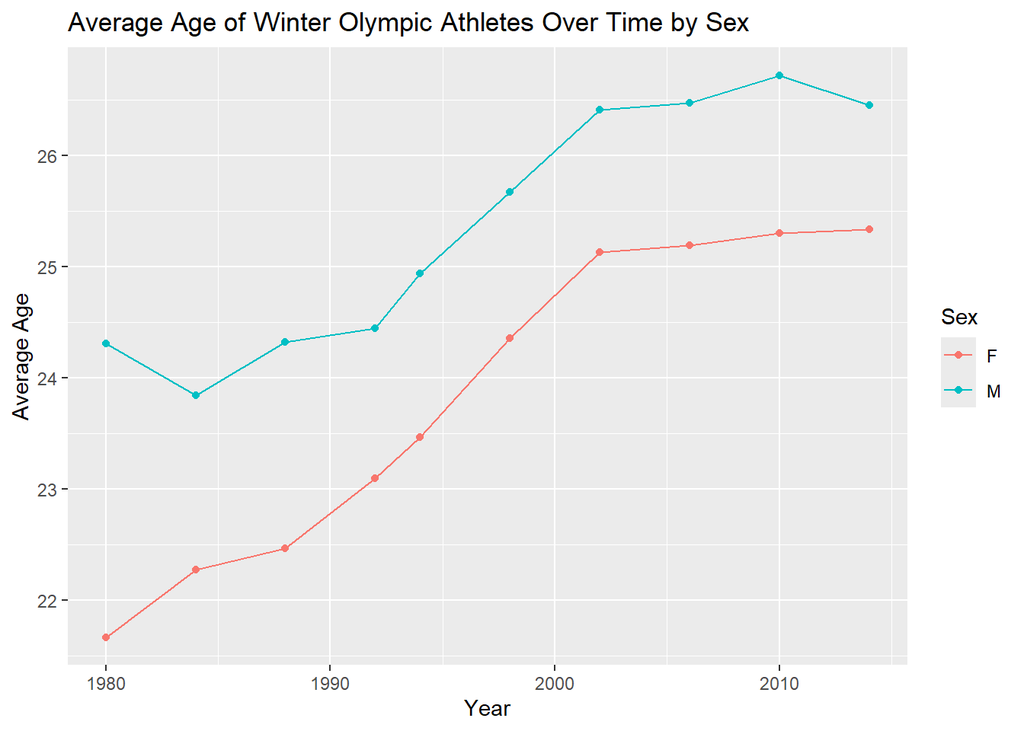

```r
new_olympics %>%
  group_by(Year, Sex) %>%
  summarize(mean_age = mean(Age, na.rm = TRUE)) %>%
  ggplot(aes(Year, mean_age, color = Sex)) +
  geom_line() +
  geom_point() +
  labs(
    title = "Average Age of Winter Olympic Athletes Over Time by Sex",
    y = "Average Age")
```

## **STATISTICAL ANALYSES**

### 1. Correlation

To explore trends over time, we begin by analyzing the relationship between athlete age and Olympic year using a correlation analysis.

```r
cor.test(new_olympics$Age, new_olympics$Year)
```

```
##
##  Pearson's product-moment correlation
##
## data:  new_olympics$Age and new_olympics$Year
## t = 37.567, df = 34481, p-value < 2.2e-16
## alternative hypothesis: true correlation is not equal to 0
## 95 percent confidence interval:
##  0.1881327 0.2084123
## sample estimates:
##       cor
## 0.1982937
```

**Interpretation:** To investigate whether the average age of Winter Olympic athletes has changed over time, we analyzed the correlation between athlete age and Olympic year.

The relationship between year and age is positive (r > 0) statistically significant (p < 0.001), but it is weak (r ≈ 0.20) and this means athlete age has increased only slightly over time. The pattern appears for both males and females, suggesting an overall trend toward slightly older athletes; this may be due to better training, recovery, and medical support, which allow athletes to compete at a high level for more years.

### 2. Linear Regression

Body size is an important factor in many winter sports. To better understand the relationship between physical characteristics, we examine whether height predicts weight among Winter Olympic athletes.

```r
linear_regression <- lm(Weight ~ Height, data = new_olympics)

summary(linear_regression)
```

```
##
## Call:
## lm(formula = Weight ~ Height, data = new_olympics)
##
## Residuals:
##     Min      1Q  Median      3Q     Max
## -44.212  -4.999  -0.572   4.399  47.719
##
## Coefficients:
##               Estimate Std. Error t value Pr(>|t|)
## (Intercept) -1.363e+02  8.268e-01  -164.9   <2e-16 ***
## Height       1.184e+00  4.719e-03   251.0   <2e-16 ***
## ---
## Signif. codes:  0 '***' 0.001 '**' 0.01 '*' 0.05 '.' 0.1 ' ' 1
##
## Residual standard error: 7.349 on 32089 degrees of freedom
##   (2413 osservazioni eliminate a causa di valori mancanti)
## Multiple R-squared:  0.6626, Adjusted R-squared:  0.6625
## F-statistic: 6.301e+04 on 1 and 32089 DF,  p-value: < 2.2e-16
```

**Interpretation:** The relationship between height and weight is statistically significant (p < 0.001) and strong (R² ≈ 0.66). On average, for every 1 cm increase in height, weight increases by about 1.18 kg. This suggests that taller athletes tend to weigh more, and height explains a large portion of the variation in weight among Winter Olympic athletes.

### 3. T-Test

After examining general trends in age and body size, we now investigate whether these characteristics differ between medal winners and non-medal winners.

```r
new_olympics <- new_olympics %>%
  mutate(Medal_Status = !is.na(Medal))
```

```r
t.test(Age ~ Medal_Status, data = new_olympics)
```

```
##
##  Welch Two Sample t-test
##
## data:  Age by Medal_Status
## t = -13.273, df = 4952.9, p-value < 2.2e-16
## alternative hypothesis: true difference in means between group FALSE and group TRUE is not equal to 0
## 95 percent confidence interval:
##  -1.2113411 -0.8995629
## sample estimates:
## mean in group FALSE  mean in group TRUE
##            25.00972            26.06517
```

**Interpretation:** The difference in age between medalists and non-medalists is statistically significant (p < 0.001) and medalists are on average about 1 year older than non-medalists (26.07 vs 25.01 years). However, while the difference is statistically significant, the size of the difference is relatively small suggesting that age alone is not a major determinant of medal success.

```r
t.test(Height ~ Medal_Status, data = new_olympics)
```

```
##
##  Welch Two Sample t-test
##
## data:  Height by Medal_Status
## t = -6.3936, df = 4925.2, p-value = 1.77e-10
## alternative hypothesis: true difference in means between group FALSE and group TRUE is not equal to 0
## 95 percent confidence interval:
##  -1.265215 -0.671396
## sample estimates:
## mean in group FALSE  mean in group TRUE
##            174.8536            175.8219
```

**Interpretation:** The difference in height between medalists and non-medalists is statistically significant (p < 0.001). Medalists are on average about 1 cm taller (175.82 cm vs 174.85 cm). However, while the difference is statistically significant, it is small in size suggesting that height alone is not a major determinant of medal success.

## **CONCLUSION**

Overall, even though some results were statistically significant, the actual differences were pretty small. Medalists were only slightly older and slightly bigger than non-medalists and this tells us that body measurements alone don’t decide who wins, experience, training, mindset, and preparation probably matter just as much, if not more. We also saw that athletes today are a little older than in the past. The change likely reflects better recovery, better nutrition, and better training methods. When it comes to countries, the pattern is clear: most nations don’t dominate everything, they tend to specialize in certain sports.

In the end, this project shows that behind every medal there isn’t just one factor; success at the Olympic level comes from a mix of physical ability, development, support systems, and long-term investment.